# GF tutorial - SSMPG2022

Olivier Francois and Clement Gain

13/09/2022

## Introduction

Gradient forests (GF) is based on the random forests (RF) algorithm. The starting point to compute genetic offset with GF is to model the allelic composition of a population using non-linear functions of environmental gradients. Genetic offsets can then be estimated by computing the difference in composition between two environments. When there are several environmental variables, the genetic offset is obtained by computing the Euclidean distance between the composition vector for the future and for the current environmental variables.

```r
# To install GF, remove the comment character in the next command line
# install.packages("gradientForest", repos="http://R-Forge.R-project.org")
# To install LEA, remove the comment character in the next command line
# devtools::install_github("bcm-uga/LEA")
# We use LEA in order to have access to the example dataset
library(gradientForest)
library(LEA)
```

This tutorial uses a simulated data set. A brief analysis of population structure and a GEA analysis using four environmental variables can be found in the LEA_tutorial_ssmpg22 file. It is highly recommended to first read the LEA tutorial in order to better understand the data.

## Short presentation of the data

The data set contains a genotypic matrix stored in an lfmm format with 200 diploid individuals (rows) genotyped at 510 SNPs (columns), a matrix with 4 correlated environmental variables (env) measured for each individual. The data were simulated according to a spatially-explicit evolutionary scenario implemented in the individual-based simulation program SLIM 3 (Haller and Messer 2019). The complex demographic scenario included colonization of the species range from a single origin, and adaptation to encountered environmental conditions. To simulate natural selection, adaptive traits were controlled by a polygenic architecture, with additive effects from two (unobserved) environmental variables. From the simulation, we known that about $30\%$ of loci were under the influence of the environment.

```r
data("offset_example")
# genotypes for 200 individuals
Y <- offset_example$geno

# Four environmental variables for 200 individuals
X <- offset_example$env
```

## Genotype-Environment Association (GEA) studies with LFMM

The complete process to identify locus under selection is described in the LEA tutorial, using an LFMM with $K = 3$ and a FDR control algorithm with a fdr level of 0.2

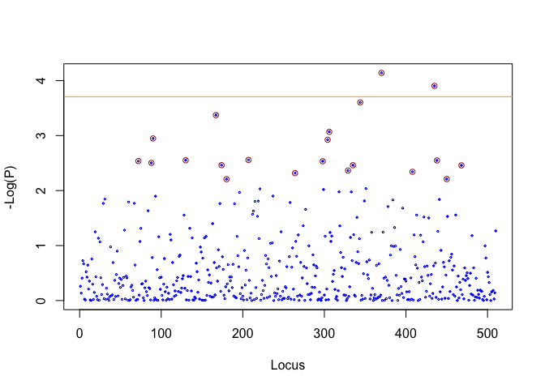

```r
# Run LFMM with K = 3

mod_lfmm2 <- lfmm2(input = Y,
                   env = X,
                   K = 3)

# Obtain the pvalue object using lfmm2.test function

pv_lfmm2 = lfmm2.test(object = mod_lfmm2,
                      input = Y,
                      env = X,
                      full = TRUE)$pvalues

# Obtaining candidate SNPs using qvalue package and a FDR level of 0.2

qv_lfmm2  <- qvalue::qvalue(pv_lfmm2, fdr.level = 0.2)

plot(-log10(pv_lfmm2 ), cex = .3, xlab = "Locus",  ylab = "-Log(P)", col = "blue")
# Orange line: Bonferonni multiple testing threshold for significance
abline(h = -log10(0.1/ncol(Y)), col = "orange")

candidates <- which(qv_lfmm2$significant)

# Circles: Candidate loci at FDR level = 30%
points(candidates, -log10(pv_lfmm2)[candidates], cex = .9, col = "brown")
```

## Genomic offset using gradient forests

We will now compute the genetic offset using the gradient forest function. To compute an offset require two types of environmental conditions. The first one can be thought of as the current environmental conditions on which the gradient forest will be train. The second is the new environmental conditions that will be use to compute an offset between future and new environmental conditions. In our simulation, an instantaneous change in environmental conditions was applied at the end of the simulation, and the loss in survival probability was measured at each sampled location. The new conditions are loaded as follows.

```r
X_pred <- offset_example$env.pred
```

Having obtained a list of candidate loci and loaded new conditions, the genetic offsets can be computed using GF

```r
# This function aims at running GF algorithm on training data

run_gradient_forest <- function(Y, X, causal_set, confounding_var=c()){
  # GF requires a dataframe object
  # We create two lists containing names for predictor (X) and names for output (OUT)
  # These lists will be used as column names in the data frame
  nb_env_var = dim(X)[2]
  var_name <- sapply(seq(1,nb_env_var), function(x) paste("X",x, sep=""))
  nb_causal <- length(causal_set)
  output_name <- sapply(seq(1,nb_causal), function(x) paste("OUT",x, sep=""))

  # This block of code check whether the user has specified variable as confounding var
  # If it's the case we will add these to the column names.
  nb_confound <- dim(confounding_var)[2]
  if (is.null(nb_confound)){
    confound_name <- c()
    df_gf <- data.frame(Y[,causal_set], X)
  }else{
    confound_name <- sapply(seq(1,nb_confound), function(x) paste("U",x, sep=""))
    df_gf <- data.frame(Y[,causal_set], X, confounding_var)
  }

  # In GF the predictor are the environmental variables and the possible confounding variables that are specified
  # The difference between environmental variables and confounding variables is that confounding variables will not
  # change in the new environmental condition
  pred_name <- c(var_name, confound_name)
  colnames(df_gf) <- c(output_name, pred_name)
  # Gradient forests requires factor column when you use SNPs value (i.e 0, 1 and 2) as opposed to allele frequency value
  for (name in output_name){
    df_gf[,name] <- as.factor(df_gf[,name])
  }

  # This command will allow us to obtain a gradient forest object
  gf <- gradientForest(data=df_gf, predictor.vars=pred_name, response.vars = output_name, ntree=500)
  return(list(gf=gf, pred_name = var_name))
}




# This function converts environmental variables into allelic composition value
# It then predict the genetic offset using the euclidean distance between
# allelic composition of current and future environmental variables

predict_gf <- function(gf, X, X_pred, pred_name){

  # We create data frame for current and new environmental conditions
  df_cur_var <- data.frame(X)
  df_fut_var <- data.frame(X_pred)
  colnames(df_cur_var) <- pred_name
  colnames(df_fut_var) <- pred_name

  # We obtain the cumulative importance value from GF for current and new environmental conditions
  currentcumimp <- predict(gf, df_cur_var)
  futurcumimp <- predict(gf, df_fut_var)

  # We compute the euclidean distance between current and new cumulative importance
  nb_ind <- nrow(X)
  genetic_offset <- c()
  for (i in seq(1,nb_ind)){
    genetic_offset <- c(genetic_offset, l2norm(futurcumimp[i,], currentcumimp[i,]))
  }

  return(genetic_offset)
}

l2norm <- function(u, v){
  return(sqrt(sum((u-v)^2)))
}

get_genetic_offset_gf <- function(Y, X, X_pred, causal_set, confounding_var = NULL){


  gf <- run_gradient_forest(Y, X, causal_set, confounding_var)
  genoffset <- predict_gf(gf$gf, X, X_pred, gf$pred_name)


  return(list(go=genoffset, varimp=gf$gf$overall.imp))
}
```

We use all the above function to obtain genetic offset from GF

```r
go_gf <- get_genetic_offset_gf(Y, X, X_pred, candidates)
```

We now compare genetic offset from GF with survival loss

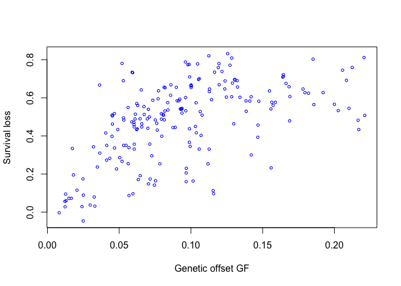

```r
survival_loss <- read.table("fitness_variation.txt", header = FALSE)[,1]

# plot the survival loss vs squared root of the genetic gap
plot(go_gf$go, survival_loss , ylab ="Survival loss",  xlab ="Genetic offset GF", cex = .6, col = "blue")
```

```r
summary(lm(survival_loss ~ go_gf$go))
```

```
##
## Call:
## lm(formula = survival_loss ~ go_gf$go)
##
## Residuals:
##      Min       1Q   Median       3Q      Max
## -0.42951 -0.11388  0.03278  0.11904  0.40218
##
## Coefficients:
##             Estimate Std. Error t value Pr(>|t|)
## (Intercept)  0.25725    0.02661   9.666   <2e-16 ***
## go_gf$go     2.32402    0.24979   9.304   <2e-16 ***
## ---
## Signif. codes:  0 '***' 0.001 '**' 0.01 '*' 0.05 '.' 0.1 ' ' 1
##
## Residual standard error: 0.1731 on 198 degrees of freedom
## Multiple R-squared:  0.3042, Adjusted R-squared:  0.3007
## F-statistic: 86.56 on 1 and 198 DF,  p-value: < 2.2e-16
```

## Correcting for population structure

Here we include the latent factors of LFMM into GF to reduce the effect of confounding due to neutral population structure.

```r
go_gf_corrected <- get_genetic_offset_gf(Y, X, X_pred, candidates, confounding_var = mod_lfmm2@U)
```

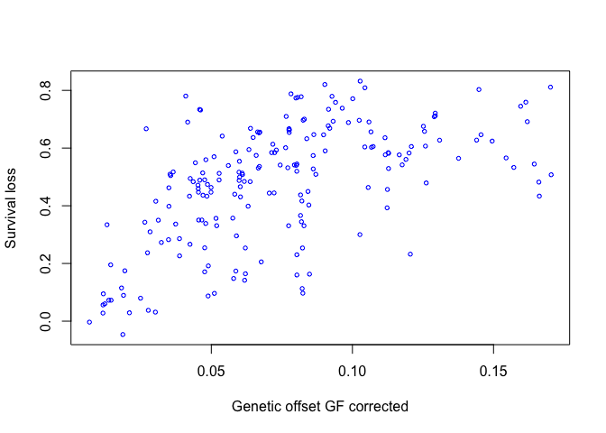

```r
plot(go_gf_corrected$go, survival_loss , ylab ="Survival loss",  xlab ="Genetic offset GF corrected", cex = .6, col = "blue")
```

```r
summary(lm(survival_loss ~ go_gf_corrected$go))
```

```
##
## Call:
## lm(formula = survival_loss ~ go_gf_corrected$go)
##
## Residuals:
##     Min      1Q  Median      3Q     Max
## -0.4051 -0.1105  0.0333  0.1203  0.4060
##
## Coefficients:
##                    Estimate Std. Error t value Pr(>|t|)
## (Intercept)         0.24823    0.02711   9.155   <2e-16 ***
## go_gf_corrected$go  3.07813    0.32577   9.449   <2e-16 ***
## ---
## Signif. codes:  0 '***' 0.001 '**' 0.01 '*' 0.05 '.' 0.1 ' ' 1
##
## Residual standard error: 0.1722 on 198 degrees of freedom
## Multiple R-squared:  0.3108, Adjusted R-squared:  0.3073
## F-statistic: 89.28 on 1 and 198 DF,  p-value: < 2.2e-16
```

In this example, using latent factors estimated in an LFMM as confounding variables did not lead to a substantial change in the values of the genetic offset.